# I2 - integrated land crop model - ARID conditions

Andreas Angourakis

26 March, 2021

## General preparation

Define a lookup function to access data using identifiers or ‘keys’:

```r
getRelatedVariableWithKey <- function(keyInCallingTable, keyInCalledTable, variableInCalledTable)
{
  return(
    sapply(keyInCallingTable, function(x) variableInCalledTable[match(x, keyInCalledTable)])
  )
}
```

Load crop table (assumed to always have the same name):

```r
cropTable <- read.csv("yield/I2_yield-exp_cropTable.csv")
```

Reorder crops for a more logical display:

WARNING: doing this manually makes the script sensitive to the value of crop-selection in NetLogo. Thus, this chunk must be uptdated if crop-selection is changed before running experiments.

```r
cropTable$crop <- factor(cropTable$crop, levels = c("proso millet", "pearl millet", "rice", "barley", "wheat 1", "wheat 2"))
```

## Terrain example 1: no river

### Experiment definition

First set any parameters to be used as identifiers of the experiment batches to retrieved:

```r
terrainRandomSeed = 0
```

### Load data

Load the terrain data in the “yield” folder (assumed to always have the same name):

```r
file_names <- paste0("yield/", list.files("yield"))

nameFilter <- grepl(paste0("I2_yield-exp_pars_terrainRandomSeed=", terrainRandomSeed, "_"), file_names)

parsData <- read.csv(file_names[nameFilter])
```

Load all experiment output files in the “yield” folder, generated with this version (I2):

```r
file_names <- paste0("yield/", list.files("yield"))

nameFilter <- grepl(paste0("I2_yield-exp_terrainRandomSeed=", terrainRandomSeed, "_"), file_names)

yieldData <- do.call(rbind, lapply(file_names[nameFilter], read.csv))
```

Force the same order of crops used by cropTable:

```r
yieldData$crop <- factor(yieldData$crop, levels = levels(cropTable$crop))
```

### Preparations

Get vector of colours to represent crops:

```r
cropColours <- rainbow(nlevels(cropTable$crop), s = 0.8, v = 0.8, end = 0.85)
```

Precalculate ranges of ARID and yield:

```r
minARID = round(min(c(yieldData$p_soil_meanARID, yieldData$p_soil_meanARID_grow), na.rm = TRUE), digits = 2)
maxARID = round(max(c(yieldData$p_soil_meanARID, yieldData$p_soil_meanARID_grow), na.rm = TRUE), digits = 2)

minYield = round(min(yieldData$yield), digits = -1)
maxYield = round(max(yieldData$yield), digits = -1)

minPrecipitation_yearlyMean = round(min(parsData$precipitation_yearlyMean, na.rm = TRUE), digits = -2)
maxPrecipitation_yearlyMean = round(max(parsData$precipitation_yearlyMean, na.rm = TRUE), digits = -2)

minPrecipitation_dailyCum_plateauValue_yearlyMean = round(min(parsData$precipitation_dailyCum_plateauValue_yearlyMean, na.rm = TRUE), digits = 2)
maxPrecipitation_dailyCum_plateauValue_yearlyMean = round(max(parsData$precipitation_dailyCum_plateauValue_yearlyMean, na.rm = TRUE), digits = 2)
```

### Summary statistics per crop

```r
yieldData_summary <- tapply(as.numeric(as.character(yieldData$yield)), yieldData$crop, summary)

yieldData_summary <- data.frame(Reduce(rbind, yieldData_summary), row.names = names(yieldData_summary))
```

```r
knitr::kable(yieldData_summary)
```

|  | Min. | X1st.Qu. | Median | Mean | X3rd.Qu. | Max. |
| --- | --- | --- | --- | --- | --- | --- |
| proso millet | 836.1164 | 939.4625 | 992.3117 | 989.6982 | 1041.4313 | 1185.0878 |
| pearl millet | 416.5021 | 445.2902 | 456.6469 | 455.1546 | 465.2043 | 496.6767 |
| rice | 0.0000 | 116.3941 | 148.4477 | 155.2655 | 183.9114 | 752.8801 |
| barley | 0.0000 | 363.5084 | 412.0610 | 335.6235 | 430.1814 | 619.8445 |
| wheat 1 | 0.0000 | 307.3053 | 348.0363 | 284.1744 | 365.3707 | 520.4710 |
| wheat 2 | 0.0000 | 320.0666 | 360.3239 | 293.8107 | 377.0618 | 542.2232 |

```r
plotName = paste0("plots/I2/yieldPerCrop_terrainRandomSeed=", terrainRandomSeed, ".png")

grScale = 2
fontRescale = 0
fontRescaleDay = 0

png(plotName, width = grScale * 500, height = grScale * 300)

par(mar = c(6,5,1,1))

boxplot(yield ~ factor(crop), data = yieldData,#[yieldData$yield > 0,], # show only non-zero yield
        ylab = expression(paste("yield (", g/m^2, ")")), xlab = "",
        las = 2,
        col = cropColours)

dev.off()
```

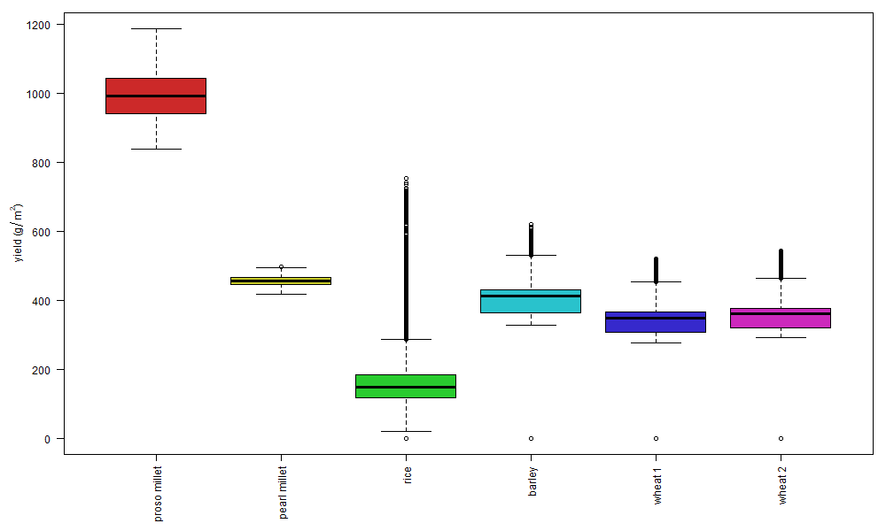

```r
knitr::include_graphics(plotName)
```

### Effect of precipitation on ARID

Plotting ARID vs precipitation yearly mean:

```r
plotName = paste0("plots/I2/ARIDvsPrecipitation_yearlyMean_terrainRandomSeed=", terrainRandomSeed, ".png")

grScale = 2
fontRescale = 0.5

png(plotName, width = grScale * 500, height = grScale * 300)

layout(matrix(c(1, 2, 3, 4, 4, 4), nrow = 3, ncol = 2),
       heights = c(10, 10, 2), widths = c(10, 3))

par(mar = c(1,5,1,1), cex.lab = 0.8 * grScale)

plot(c(minPrecipitation_yearlyMean, maxPrecipitation_yearlyMean),
     c(minARID, maxARID),
     xaxt ='n',
     xlab = "",
     ylab = "mean ARID (current year)")


for (aCrop in levels(yieldData$crop))
{
  points(getRelatedVariableWithKey(keyInCallingTable =  yieldData$randomSeed[yieldData$crop == aCrop],
                                   keyInCalledTable = parsData$randomSeed,
                                   variableInCalledTable =parsData$precipitation_yearlyMean),
         yieldData$p_soil_meanARID[yieldData$crop == aCrop],
         col = cropColours[match(aCrop, levels(yieldData$crop))],
         pch = 20
  )
  abline(lm(p_soil_meanARID ~ precipitation_yearlyMean,
            data = data.frame(cbind(
              p_soil_meanARID = yieldData[yieldData$crop == aCrop, "p_soil_meanARID"],
              precipitation_yearlyMean = getRelatedVariableWithKey(yieldData$randomSeed[yieldData$crop == aCrop],
                                                                   parsData$randomSeed,
                                                                   parsData$precipitation_yearlyMean)))),
         col = cropColours[match(aCrop, levels(yieldData$crop))],
         lwd = 2)
}

plot(c(minPrecipitation_yearlyMean, maxPrecipitation_yearlyMean),
     c(minARID, maxARID),
     xaxt ='n',
     xlab = "",
     ylab = "mean ARID (grow seasons)")

for (aCrop in levels(yieldData$crop))
{
  points(getRelatedVariableWithKey(keyInCallingTable =  yieldData$randomSeed[yieldData$crop == aCrop],
                                   keyInCalledTable = parsData$randomSeed,
                                   variableInCalledTable =parsData$precipitation_yearlyMean),
         yieldData$p_soil_meanARID_grow[yieldData$crop == aCrop],
         col = cropColours[match(aCrop, levels(yieldData$crop))],
         pch = 20
  )
  abline(lm(p_soil_meanARID_grow ~ precipitation_yearlyMean,
            data = data.frame(cbind(
              p_soil_meanARID_grow = yieldData[yieldData$crop == aCrop, "p_soil_meanARID_grow"],
              precipitation_yearlyMean = getRelatedVariableWithKey(yieldData$randomSeed[yieldData$crop == aCrop],
                                                                   parsData$randomSeed,
                                                                   parsData$precipitation_yearlyMean)))),
         col = cropColours[match(aCrop, levels(yieldData$crop))],
         lwd = 2)
}

par(mar = c(1, 1, 1, 0.1))

plot(c(minPrecipitation_yearlyMean, maxPrecipitation_yearlyMean), c(0, 1), ann = F, bty = 'n', type = 'n', xaxt = 'n', yaxt = 'n')

axis(3,
     at = seq(minPrecipitation_yearlyMean, maxPrecipitation_yearlyMean, by = 50),
     tck = 0, lwd = 0)

mtext("precipitation yearly mean (mm)", side = 1, line = -2)

par(mar = c(0, 0, 0, 0), cex = 0.8 * grScale)

plot(c(0, 1), c(0, 1), ann = F, bty = 'n', type = 'n', xaxt = 'n', yaxt = 'n')

legend(x = 0, y = 1,
       legend = stringi::stri_c(cropTable$S_water, " (", levels(yieldData$crop), ")"),
       title = "S_water (Crop-cultivar)",
       fill = cropColours)

dev.off()
```

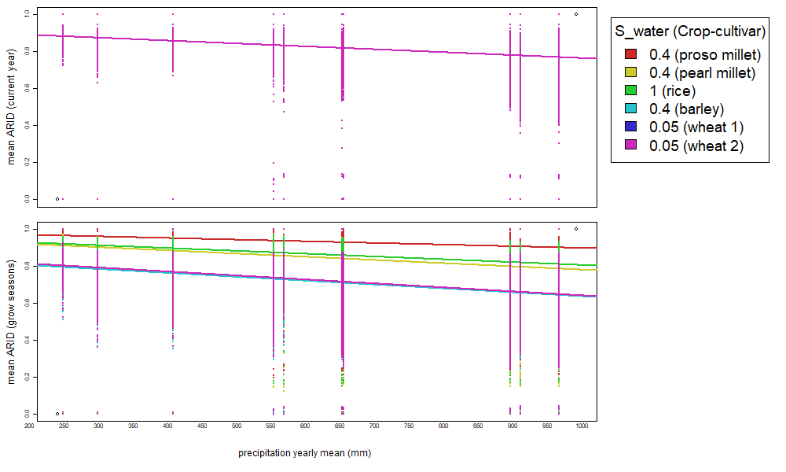

```r
knitr::include_graphics(plotName)
```

Plotting ARID vs precipitation seasonal balance (plateau value):

```r
plotName = paste0("plots/I2/ARIDvsPrecipitation_dailyCum_plateauValue_yearlyMean_terrainRandomSeed=", terrainRandomSeed, ".png")

grScale = 2
fontRescale = 0.5

png(plotName, width = grScale * 500, height = grScale * 300)

layout(matrix(c(1, 2, 3, 4, 4, 4), nrow = 3, ncol = 2),
       heights = c(10, 10, 2), widths = c(10, 3))

par(mar = c(1,5,1,1), cex.lab = 0.8 * grScale)

plot(c(minPrecipitation_dailyCum_plateauValue_yearlyMean, maxPrecipitation_dailyCum_plateauValue_yearlyMean),
     c(minARID, maxARID),
     xaxt ='n',
     xlab = "",
     ylab = "mean ARID (current year)")

for (aCrop in levels(yieldData$crop))
{
  points(getRelatedVariableWithKey(keyInCallingTable =  yieldData$randomSeed[yieldData$crop == aCrop],
                                   keyInCalledTable = parsData$randomSeed,
                                   variableInCalledTable =parsData$precipitation_dailyCum_plateauValue_yearlyMean),
         yieldData$p_soil_meanARID[yieldData$crop == aCrop],
         col = cropColours[match(aCrop, levels(yieldData$crop))],
         pch = 20
  )
  abline(lm(p_soil_meanARID ~ precipitation_yearlyMean,
            data = data.frame(cbind(
              p_soil_meanARID = yieldData[yieldData$crop == aCrop, "p_soil_meanARID"],
              precipitation_yearlyMean = getRelatedVariableWithKey(yieldData$randomSeed[yieldData$crop == aCrop],
                                                                   parsData$randomSeed,
                                                                   parsData$precipitation_dailyCum_plateauValue_yearlyMean)))),
         col = cropColours[match(aCrop, levels(yieldData$crop))],
         lwd = 2)
}

plot(c(minPrecipitation_dailyCum_plateauValue_yearlyMean, maxPrecipitation_dailyCum_plateauValue_yearlyMean),
     c(minARID, maxARID),
     xaxt ='n',
     xlab = "",
     ylab = "mean ARID (grow seasons)")

for (aCrop in levels(yieldData$crop))
{
  points(getRelatedVariableWithKey(keyInCallingTable =  yieldData$randomSeed[yieldData$crop == aCrop],
                                   keyInCalledTable = parsData$randomSeed,
                                   variableInCalledTable =parsData$precipitation_dailyCum_plateauValue_yearlyMean),
         yieldData$p_soil_meanARID_grow[yieldData$crop == aCrop],
         col = cropColours[match(aCrop, levels(yieldData$crop))],
         pch = 20
  )
  abline(lm(p_soil_meanARID_grow ~ precipitation_yearlyMean,
            data = data.frame(cbind(
              p_soil_meanARID_grow = yieldData[yieldData$crop == aCrop, "p_soil_meanARID_grow"],
              precipitation_yearlyMean = getRelatedVariableWithKey(yieldData$randomSeed[yieldData$crop == aCrop],
                                                                   parsData$randomSeed,
                                                                   parsData$precipitation_dailyCum_plateauValue_yearlyMean)))),
         col = cropColours[match(aCrop, levels(yieldData$crop))],
         lwd = 2)
}

par(mar = c(1, 1, 1, 0.1))

plot(c(minPrecipitation_dailyCum_plateauValue_yearlyMean, maxPrecipitation_dailyCum_plateauValue_yearlyMean), c(0, 1),
     ann = F, bty = 'n', type = 'n', xaxt = 'n', yaxt = 'n')

axis(3,
     at = seq(minPrecipitation_dailyCum_plateauValue_yearlyMean, maxPrecipitation_dailyCum_plateauValue_yearlyMean, by = 0.1),
     tck = 0, lwd = 0)

mtext("precipitation plateau value (i.e. winter / summer) yearly mean (mm)", side = 1, line = -2)

par(mar = c(0, 0, 0, 0), cex = 0.8 * grScale)

plot(c(0, 1), c(0, 1), ann = F, bty = 'n', type = 'n', xaxt = 'n', yaxt = 'n')

legend(x = 0, y = 1,
       legend = stringi::stri_c(cropTable$S_water, " (", levels(yieldData$crop), ")"),
       title = "S_water (Crop-cultivar)",
       fill = cropColours)

dev.off()
```

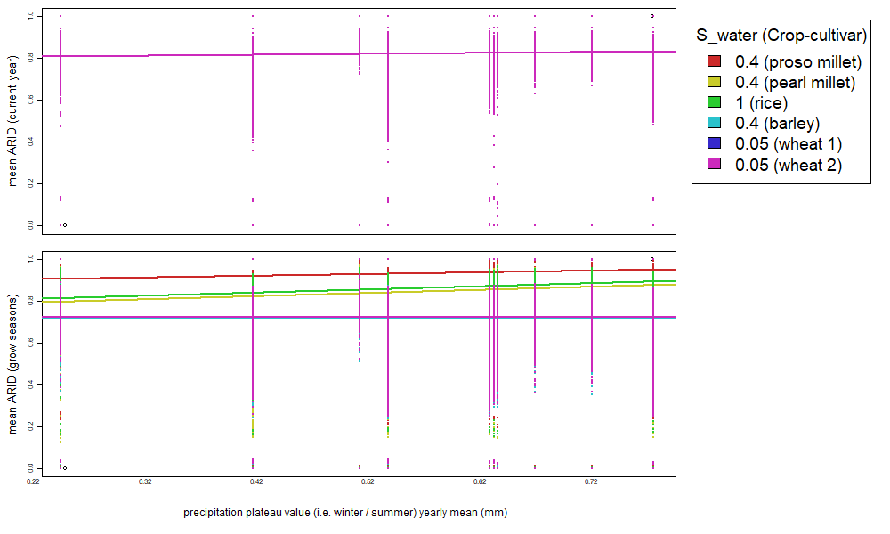

```r
knitr::include_graphics(plotName)
```

### Effect of ARID on yield

Plotting absolute values of yield vs ARID:

```r
plotName = paste0("plots/I2/yieldVsARID_terrainRandomSeed=", terrainRandomSeed, ".png")

grScale = 2
fontRescale = 0
fontRescaleDay = 0

png(plotName, width = grScale * 500, height = grScale * 300)

layout(matrix(c(1, 2, 3, 3), nrow = 2, ncol = 2, byrow = FALSE),
       widths = c(10, 3))

par(mar = c(5,5,1,1), cex.lab = 0.8 * grScale)

plot(c(minARID, maxARID),
     c(minYield, maxYield),
     xlab = "mean ARID (current year)",
     ylab = expression(paste("yield (", g/m^2, ")")))

for (aCrop in levels(yieldData$crop))
{
  points(yieldData$p_soil_meanARID[yieldData$crop == aCrop],
         yieldData$yield[yieldData$crop == aCrop],
         col = cropColours[match(aCrop, levels(yieldData$crop))],
         pch = 20
  )
  abline(lm(yield ~ p_soil_meanARID, data = yieldData[yieldData$crop == aCrop,]),
         col = cropColours[match(aCrop, levels(yieldData$crop))],
         lwd = 2)
}

plot(c(minARID, maxARID),
     c(minYield, maxYield),
     xlab = "mean ARID (grow season)",
     ylab = expression(paste("yield (", g/m^2, ")")))

for (aCrop in levels(yieldData$crop))
{
  points(yieldData$p_soil_meanARID_grow[yieldData$crop == aCrop],
         yieldData$yield[yieldData$crop == aCrop],
         col = cropColours[match(aCrop, levels(yieldData$crop))],
         pch = 20
  )
  abline(lm(yield ~ p_soil_meanARID_grow, data = yieldData[yieldData$crop == aCrop,]),
         col = cropColours[match(aCrop, levels(yieldData$crop))],
         lwd = 2)
}

par(mar = c(0, 0, 0, 0), cex = 0.8 * grScale)

plot(c(0, 1), c(0, 1), ann = F, bty = 'n', type = 'n', xaxt = 'n', yaxt = 'n')

legend(x = 0, y = 1,
       legend = stringi::stri_c(cropTable$S_water, " (", levels(yieldData$crop), ")"),
       title = "S_water (Crop-cultivar)",
       fill = cropColours)

dev.off()
```

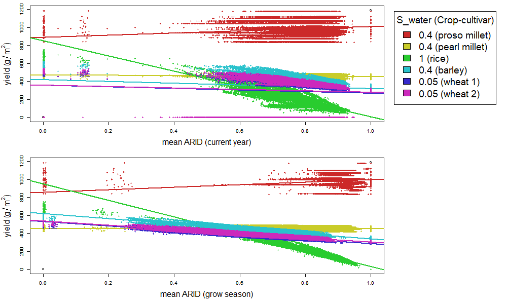

```r
knitr::include_graphics(plotName)
```

Calculate correlation and linear models fitness:

```r
linearModels.table <- data.frame(
  levels(yieldData$crop),
  numeric(nlevels(yieldData$crop)),
  numeric(nlevels(yieldData$crop)),
  numeric(nlevels(yieldData$crop)),
  numeric(nlevels(yieldData$crop)),
  numeric(nlevels(yieldData$crop)),
  numeric(nlevels(yieldData$crop))
)

names(linearModels.table) <- c("crop", "correlation_Pearson", "intercept", "intercept_p", "speed", "speed_p", "adjrsquared")

for (aCrop in levels(yieldData$crop))
{
  linearModels.table$correlation_Pearson[linearModels.table$crop == aCrop] <-
    cor(x = yieldData$p_soil_meanARID_grow[yieldData$crop == aCrop], y = yieldData$yield[yieldData$crop == aCrop], use = "pairwise.complete.obs")

  linearModel <- lm(yield ~ p_soil_meanARID_grow, data = yieldData[yieldData$crop == aCrop,])

  linearModels.table$intercept[linearModels.table$crop == aCrop] <- summary(linearModel)$coefficients[1,1]
  linearModels.table$intercept_p[linearModels.table$crop == aCrop] <- summary(linearModel)$coefficients[1,4]
  linearModels.table$speed[linearModels.table$crop == aCrop] <- summary(linearModel)$coefficients[2,1]
  linearModels.table$speed_p[linearModels.table$crop == aCrop] <- summary(linearModel)$coefficients[2,4]
  linearModels.table$adjrsquared[linearModels.table$crop == aCrop] <- summary(linearModel)$adj.r.squared
}
```

```r
knitr::kable(linearModels.table)
```

| crop | correlation_Pearson | intercept | intercept_p | speed | speed_p | adjrsquared |
| --- | --- | --- | --- | --- | --- | --- |
| proso millet | 0.1025631 | 854.8738 | 0 | 144.19850 | 0 | 0.0105113 |
| pearl millet | -0.0183592 | 458.7959 | 0 | -4.28521 | 0 | 0.0003291 |
| rice | -0.9644577 | 948.0909 | 0 | -915.25606 | 0 | 0.9301781 |
| barley | -0.9195643 | 619.1468 | 0 | -277.17607 | 0 | 0.8455969 |
| wheat 1 | -0.9055386 | 532.3993 | 0 | -244.28879 | 0 | 0.8199983 |
| wheat 2 | -0.9107673 | 540.6304 | 0 | -239.02980 | 0 | 0.8294954 |

### Yield by crop and precipitation conditions

Plotting absolute values of yield vs precipitation yearly mean:

```r
plotName = paste0("plots/I2/yieldVsprecipitation_yearlyMean_terrainRandomSeed=", terrainRandomSeed, ".png")

grScale = 2
fontRescale = 0
fontRescaleDay = 0

png(plotName, width = grScale * 500, height = grScale * 300)

layout(matrix(c(1, 2), nrow = 1, ncol = 2, byrow = FALSE),
       widths = c(10, 3))

par(mar = c(5,5,1,1), cex.lab = 0.8 * grScale)

plot(c(minPrecipitation_yearlyMean, maxPrecipitation_yearlyMean),
     c(minYield, maxYield),
     xlab = "precipitation yearly mean (mm)",
     ylab = expression(paste("yield (", g/m^2, ")")))

for (aCrop in levels(yieldData$crop))
{
  points(getRelatedVariableWithKey(keyInCallingTable =  yieldData$randomSeed[yieldData$crop == aCrop],
                                   keyInCalledTable = parsData$randomSeed,
                                   variableInCalledTable = parsData$precipitation_yearlyMean),
         yieldData$yield[yieldData$crop == aCrop],
         col = cropColours[match(aCrop, levels(yieldData$crop))],
         pch = 20
  )
  abline(lm(yield ~ precipitation_yearlyMean,
            data = data.frame(cbind(
              yield = yieldData[yieldData$crop == aCrop, "yield"],
              precipitation_yearlyMean = getRelatedVariableWithKey(yieldData$randomSeed[yieldData$crop == aCrop],
                                                                   parsData$randomSeed,
                                                                   parsData$precipitation_yearlyMean)))),
         col = cropColours[match(aCrop, levels(yieldData$crop))],
         lwd = 2)
}

par(mar = c(0, 0, 0, 0), cex = 0.8 * grScale)

plot(c(0, 1), c(0, 1), ann = F, bty = 'n', type = 'n', xaxt = 'n', yaxt = 'n')

legend(x = 0, y = 1,
       legend = stringi::stri_c(cropTable$S_water, " (", levels(yieldData$crop), ")"),
       title = "S_water (Crop-cultivar)",
       fill = cropColours)

dev.off()
```

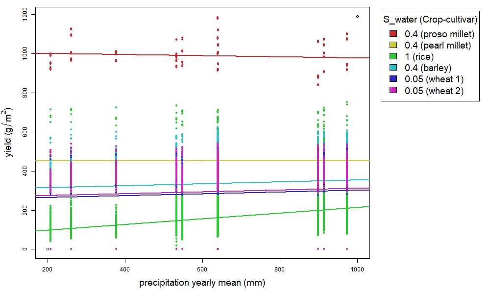

```r
knitr::include_graphics(plotName)
```

Calculate correlation and linear models fitness:

```r
linearModels.table <- data.frame(
  levels(yieldData$crop),
  numeric(nlevels(yieldData$crop)),
  numeric(nlevels(yieldData$crop)),
  numeric(nlevels(yieldData$crop)),
  numeric(nlevels(yieldData$crop)),
  numeric(nlevels(yieldData$crop)),
  numeric(nlevels(yieldData$crop))
)

names(linearModels.table) <- c("crop", "correlation_Pearson", "intercept", "intercept_p", "speed", "speed_p", "adjrsquared")

for (aCrop in levels(yieldData$crop))
{
  linearModels.table$correlation_Pearson[linearModels.table$crop == aCrop] <-
    cor(x = getRelatedVariableWithKey(keyInCallingTable =  yieldData$randomSeed[yieldData$crop == aCrop],
                                   keyInCalledTable = parsData$randomSeed,
                                   variableInCalledTable = parsData$precipitation_yearlyMean),
        y = yieldData$yield[yieldData$crop == aCrop], use = "pairwise.complete.obs")

  linearModel <- lm(yield ~ precipitation_yearlyMean,
            data = data.frame(cbind(
              yield = yieldData[yieldData$crop == aCrop, "yield"],
              precipitation_yearlyMean = getRelatedVariableWithKey(yieldData$randomSeed[yieldData$crop == aCrop],
                                                                   parsData$randomSeed,
                                                                   parsData$precipitation_yearlyMean))))

  linearModels.table$intercept[linearModels.table$crop == aCrop] <- summary(linearModel)$coefficients[1,1]
  linearModels.table$intercept_p[linearModels.table$crop == aCrop] <- summary(linearModel)$coefficients[1,4]
  linearModels.table$speed[linearModels.table$crop == aCrop] <- summary(linearModel)$coefficients[2,1]
  linearModels.table$speed_p[linearModels.table$crop == aCrop] <- summary(linearModel)$coefficients[2,4]
  linearModels.table$adjrsquared[linearModels.table$crop == aCrop] <- summary(linearModel)$adj.r.squared
}
```

```r
knitr::kable(linearModels.table)
```

| crop | correlation_Pearson | intercept | intercept_p | speed | speed_p | adjrsquared |
| --- | --- | --- | --- | --- | --- | --- |
| proso millet | -0.1052715 | 1007.77738 | 0 | -0.0301536 | 0 | 0.0110742 |
| pearl millet | 0.0735388 | 451.89202 | 0 | 0.0054414 | 0 | 0.0054000 |
| rice | 0.5482750 | 68.75859 | 0 | 0.1442817 | 0 | 0.3005999 |
| barley | 0.0766424 | 305.03836 | 0 | 0.0510118 | 0 | 0.0058661 |
| wheat 1 | 0.0802088 | 257.03871 | 0 | 0.0452585 | 0 | 0.0064255 |
| wheat 2 | 0.0779024 | 266.61296 | 0 | 0.0453621 | 0 | 0.0060608 |

Plotting absolute values of yield vs precipitation seasonal balance (plateau value):

```r
plotName = paste0("plots/I2/yieldVsprecipitation_dailyCum_plateauValue_yearlyMean_terrainRandomSeed=", terrainRandomSeed, ".png")

grScale = 2
fontRescale = 0
fontRescaleDay = 0

png(plotName, width = grScale * 500, height = grScale * 300)

layout(matrix(c(1, 2), nrow = 1, ncol = 2, byrow = FALSE),
       widths = c(10, 3))

par(mar = c(5,5,1,1), cex.lab = 0.8 * grScale)

plot(c(minPrecipitation_dailyCum_plateauValue_yearlyMean, maxPrecipitation_dailyCum_plateauValue_yearlyMean),
     c(minYield, maxYield),
     xlab = "precipitation plateau value (i.e. winter / summer) yearly mean (mm)",
     ylab = expression(paste("yield (", g/m^2, ")")))

for (aCrop in levels(yieldData$crop))
{
  points(getRelatedVariableWithKey(keyInCallingTable =  yieldData$randomSeed[yieldData$crop == aCrop],
                                   keyInCalledTable = parsData$randomSeed,
                                   variableInCalledTable =parsData$precipitation_dailyCum_plateauValue_yearlyMean),
         yieldData$yield[yieldData$crop == aCrop],
         col = cropColours[match(aCrop, levels(yieldData$crop))],
         pch = 20
  )
  abline(lm(yield ~ precipitation_yearlyMean,
            data = data.frame(cbind(
              yield = yieldData[yieldData$crop == aCrop, "yield"],
              precipitation_yearlyMean = getRelatedVariableWithKey(yieldData$randomSeed[yieldData$crop == aCrop],
                                                                   parsData$randomSeed,
                                                                   parsData$precipitation_dailyCum_plateauValue_yearlyMean)))),
         col = cropColours[match(aCrop, levels(yieldData$crop))],
         lwd = 2)
}

par(mar = c(0, 0, 0, 0), cex = 0.8 * grScale)

plot(c(0, 1), c(0, 1), ann = F, bty = 'n', type = 'n', xaxt = 'n', yaxt = 'n')

legend(x = 0, y = 1,
       legend = levels(yieldData$crop),
       title = "Crop-cultivar",
       fill = cropColours)

dev.off()
```

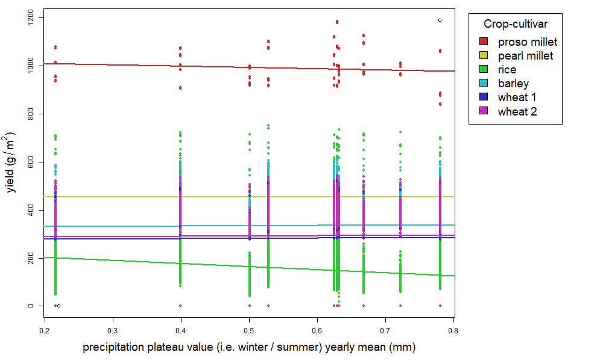

```r
knitr::include_graphics(plotName)
```

Calculate correlation and linear models fitness:

```r
linearModels.table <- data.frame(
  levels(yieldData$crop),
  numeric(nlevels(yieldData$crop)),
  numeric(nlevels(yieldData$crop)),
  numeric(nlevels(yieldData$crop)),
  numeric(nlevels(yieldData$crop)),
  numeric(nlevels(yieldData$crop)),
  numeric(nlevels(yieldData$crop))
)

names(linearModels.table) <- c("crop", "correlation_Pearson", "intercept", "intercept_p", "speed", "speed_p", "adjrsquared")

for (aCrop in levels(yieldData$crop))
{
  linearModels.table$correlation_Pearson[linearModels.table$crop == aCrop] <-
    cor(x = getRelatedVariableWithKey(keyInCallingTable =  yieldData$randomSeed[yieldData$crop == aCrop],
                                      keyInCalledTable = parsData$randomSeed,
                                      variableInCalledTable =parsData$precipitation_dailyCum_plateauValue_yearlyMean),
        y = yieldData$yield[yieldData$crop == aCrop], use = "pairwise.complete.obs")

  linearModel <- lm(yield ~ precipitation_yearlyMean,
                    data = data.frame(cbind(
                      yield = yieldData[yieldData$crop == aCrop, "yield"],
                      precipitation_yearlyMean = getRelatedVariableWithKey(yieldData$randomSeed[yieldData$crop == aCrop],
                                                                           parsData$randomSeed,
                                                                           parsData$precipitation_dailyCum_plateauValue_yearlyMean))))

  linearModels.table$intercept[linearModels.table$crop == aCrop] <- summary(linearModel)$coefficients[1,1]
  linearModels.table$intercept_p[linearModels.table$crop == aCrop] <- summary(linearModel)$coefficients[1,4]
  linearModels.table$speed[linearModels.table$crop == aCrop] <- summary(linearModel)$coefficients[2,1]
  linearModels.table$speed_p[linearModels.table$crop == aCrop] <- summary(linearModel)$coefficients[2,4]
  linearModels.table$adjrsquared[linearModels.table$crop == aCrop] <- summary(linearModel)$adj.r.squared
}
```

```r
knitr::kable(linearModels.table)
```

| crop | correlation_Pearson | intercept | intercept_p | speed | speed_p | adjrsquared |
| --- | --- | --- | --- | --- | --- | --- |
| proso millet | -0.1185931 | 1021.1229 | 0 | -55.112538 | 0.0000000 | 0.0140564 |
| pearl millet | 0.0309541 | 453.0357 | 0 | 3.716028 | 0.0000000 | 0.0009502 |
| rice | -0.3001293 | 228.3298 | 0 | -128.139731 | 0.0000000 | 0.0900703 |
| barley | 0.0101817 | 329.3544 | 0 | 10.994736 | 0.0003184 | 0.0000957 |
| wheat 1 | 0.0117437 | 278.0443 | 0 | 10.750913 | 0.0000329 | 0.0001299 |
| wheat 2 | 0.0112808 | 287.7340 | 0 | 10.657274 | 0.0000665 | 0.0001193 |